# Bright spots in U.S. agriculture

Emily Burchfield and Britta Schumacher

## Extended Data

All scripts used in the analyses presented in the paper are available at https://github.com/eburchfield/Bright_spots.

### Data overview

#### **Figure 1: Land resource regions**

Land Resource Region boundaries and average corn yield (bu/ac) recorded in USDA Census years between 1997 and 2017. The Florida Subtropical Fruit, Truck Crop, and Range Region (6) and the Northwestern Forest, Forage, and Specialty Crop Region (13) were dropped from the models as less than ten county-year yield observations were available over the period of interest for these regions

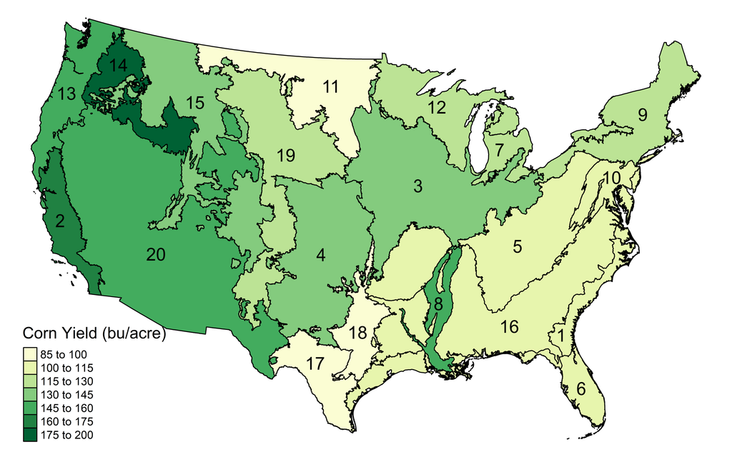

#### **Table 1: LRR summary data**

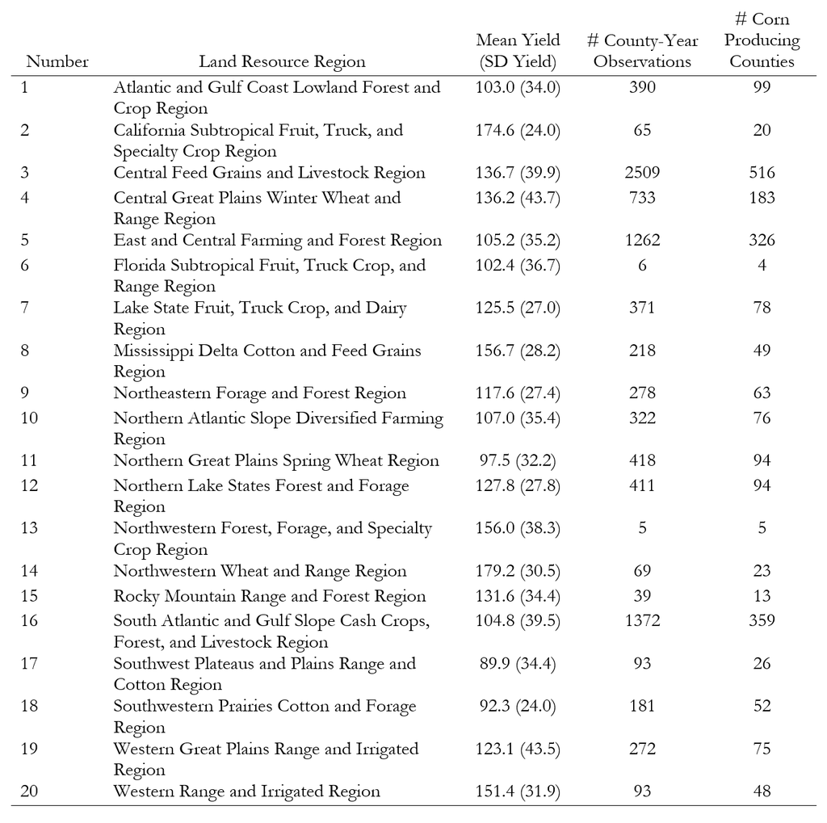

#### **Table 2: Descriptive statistics for actionable predictors**

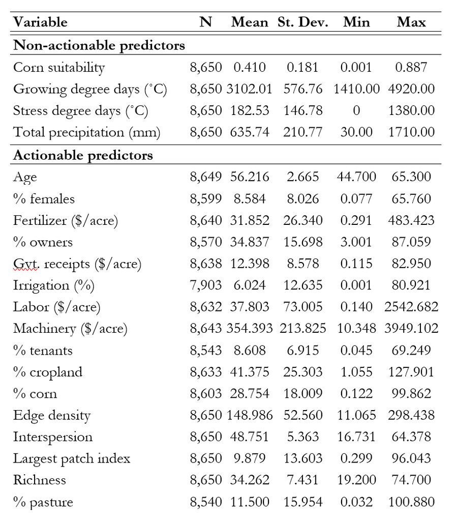

### Null model results

#### **Model specification:**

```r
# Priors
apar <- 0.5
lmod <- lm(YIELD ~ GDD + SDD + EFP + EXP + CORN_SUIT + factor(YEAR), null)
bpar <- apar*var(residuals(lmod))
lgprior_iid <- list(prec = list(prior="loggamma", param = c(apar,bpar)))
sdres <- sd(residuals(lmod))
lgprior_bym <- list(prec = list(prior="pc.prec", param = c(3*sdres, 0.01)))
u <- 0.6

# Formula
formula <- YIELD ~ 1 + f(ID, model="bym2", # county-level spatial structure
    graph=hadj,
    scale.model=TRUE,
    constr = TRUE,
    hyper= lgprior_bym) +
  CORN_SUIT +
  f(LRR, model = "iid", hyper = lgprior_iid) +
  f(GDD, model = "rw1", scale.model = T, constr = T, hyper = list(theta = list(prior = "pc.prec",
                                                                   param = c(u, 0.01)))) +
  f(SDD, model = "rw1", scale.model = T, constr = T, hyper = list(theta = list(prior = "pc.prec",
                                                                   param = c(u, 0.01)))) +
  f(TP, model = "rw1", scale.model = T, constr = T, hyper = list(theta = list(prior = "pc.prec",
                                                                   param = c(u, 0.01)))) +
  factor(YEAR)

modr <- inla(formula, data=null, family="gaussian",
           control.predictor = list(compute=T),
           control.compute = list(dic=T, cpo=T))
```

#### **Table 3: Summary of null model results**

```
##
## Call:
##    c("inla(formula = formula, family = \"gaussian\", data = null,
##    control.compute = list(dic = T, ", " cpo = T), control.predictor =
##    list(compute = T))")
## Time used:
##     Pre = 50, Running = 729, Post = 2.98, Total = 782
## Fixed effects:
##                    mean    sd 0.025quant 0.5quant 0.975quant   mode kld
## (Intercept)      70.022 7.534     55.230   70.022     84.801 70.022   0
## CORN_SUIT        65.381 4.210     57.115   65.381     73.641 65.381   0
## factor(YEAR)2002  5.977 0.705      4.592    5.977      7.361  5.977   0
## factor(YEAR)2007 22.563 0.714     21.161   22.563     23.963 22.563   0
## factor(YEAR)2012 21.085 0.759     19.594   21.085     22.574 21.085   0
## factor(YEAR)2017 43.802 0.683     42.461   43.802     45.143 43.802   0
##
## Random effects:
##   Name     Model
##     ID BYM2 model
##    LRR IID model
##    GDD RW1 model
##    SDD RW1 model
##    TP RW1 model
##
## Model hyperparameters:
##                                          mean    sd 0.025quant 0.5quant
## Precision for the Gaussian observations 0.004 0.000      0.004    0.004
## Precision for ID                        0.004 0.000      0.003    0.004
## Phi for ID                              0.129 0.016      0.103    0.128
## Precision for LRR                       0.001 0.000      0.001    0.001
## Precision for GDD                       0.032 0.010      0.014    0.032
## Precision for SDD                       0.017 0.002      0.013    0.017
## Precision for TP                        0.126 0.031      0.082    0.121
##                                         0.975quant  mode
## Precision for the Gaussian observations      0.004 0.004
## Precision for ID                             0.004 0.004
## Phi for ID                                   0.164 0.123
## Precision for LRR                            0.002 0.001
## Precision for GDD                            0.052 0.031
## Precision for SDD                            0.022 0.016
## Precision for TP                             0.200 0.110
##
## Expected number of effective parameters(stdev): 1607.18(0.00)
## Number of equivalent replicates : 5.38
##
## Deviance Information Criterion (DIC) ...............: 77583.77
## Deviance Information Criterion (DIC, saturated) ....: 13517.31
## Effective number of parameters .....................: 1548.70
##
## Marginal log-Likelihood:  -40655.54
## CPO and PIT are computed
##
## Posterior marginals for the linear predictor and
##  the fitted values are computed
```

The proportion of spatial variance is 0.5184896 suggesting that a significant amount of the variability is explained by spatial structure.

#### **Table 4: Null model diagnostics**

|  | Null |
| --- | --- |
| DIC | 77583.775 |
| CPO | -39281.003 |
| MSE | 315.705 |
| R2 | 0.718 |

The **deviance information criterion (DIC)** is a generalization of the AIC (Akaike information criterion) developed for Bayesian model comparison that examines trade-offs between model fit (log-likelihood) and model complexity (effective number of parameters). Models with smaller DIC are better supported by the data.

The **conditional predictive ordinate (CPO)** is a leave-one-out-cross-validation diagnostic that estimates the probability of observing a value in the predictive distribution given a model fitted to all the observed data except that value. Larger values of CPO indicate a better model fit.

#### **Table 5: Probability integral transform (PIT)**

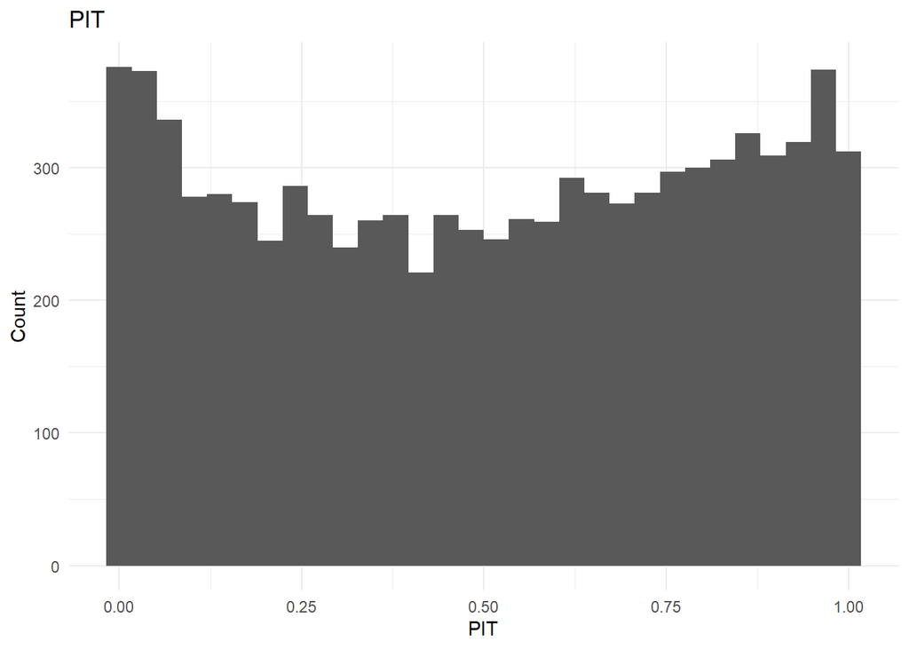

The **probability integral transform (PIT)** is a leave-one-out-cross-validation check that evaluates the predictive performance of the model where a uniform distribution of PIT means the predictive distribution matches well with the data.

#### **Table 6: PPC scatter**

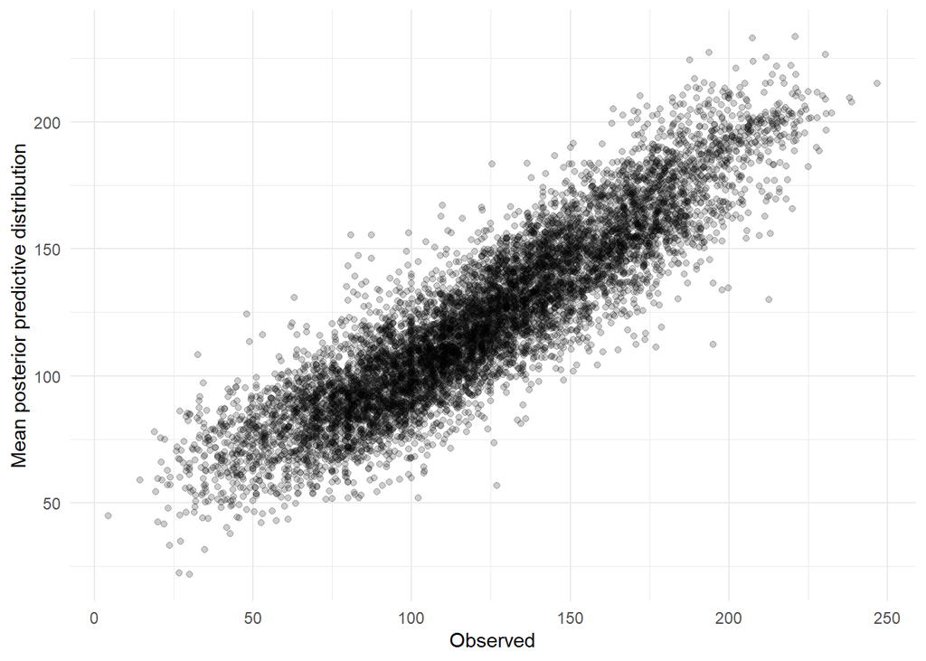

The PPC shows a scatter-plot of the posterior means for the predictive distribution and observed values, where points scattered along a line of slope 1 indicate a very good fit.